# Algoritmos de Ordenação e Busca

Nessa aula termos uma introdução aos algoritmos de ordenação Bubble Sort e a analise de complexidade desse algortimo.

No vídeo a seguir é apresentado a visão geral dos principais algoritmos de ordenação:

```python
HTML('<iframe width="560" height="315" src="https://www.youtube.com/embed/rQTQF46o16k" frameborder="0" allow="autoplay; encrypted-media" allowfullscreen></iframe>')
```

[video not shown]

## Algoritmo de Ordenação Por Troca (Bubble Sort)

1. São efetuadas comparações entre os dados armazenados num vetor de tamanho n.
2. Cada elemento da posição i é comparado como o elemento da posição i+1
3. Quando a ordenação procurada é encontrada, uma troca de posição entreo os elementos é feita.

```python
HTML('<iframe width="560" height="315" src="https://www.youtube.com/embed/lyZQPjUT5B4" frameborder="0" allow="autoplay; encrypted-media" allowfullscreen></iframe>')
```

[video not shown]

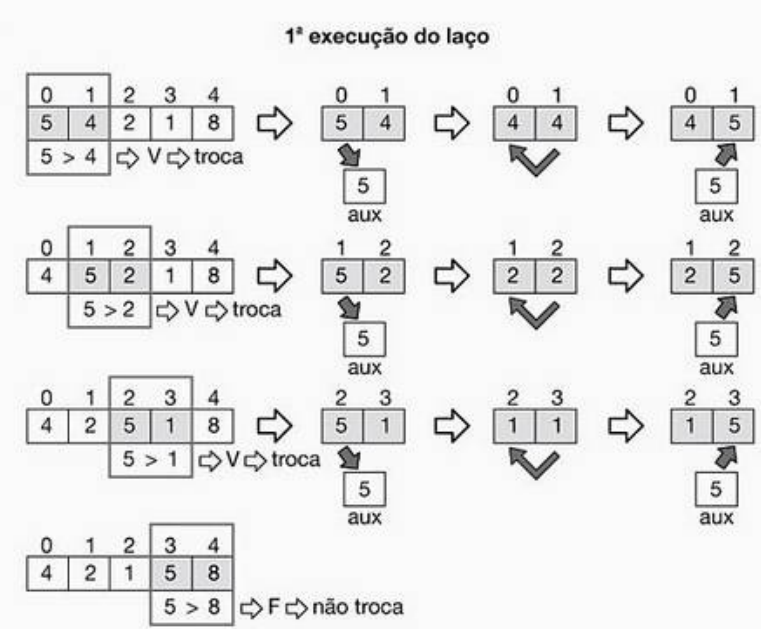

```python
Image(filename='./imagens/bubbleSort01.png')
```

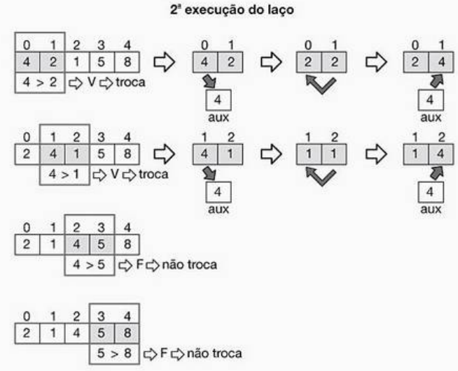

```python
Image(filename='./imagens/bubbleSort02.png')
```

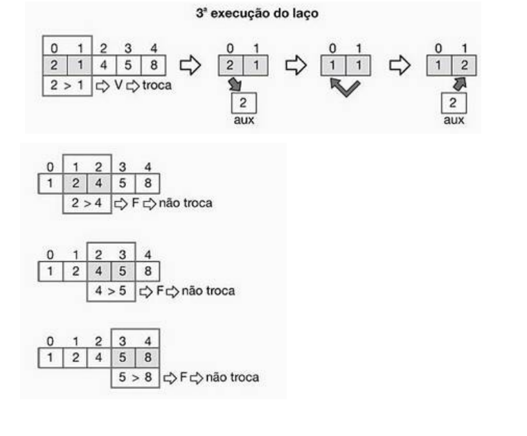

```python
Image(filename='./imagens/bubbleSort03.png')
```

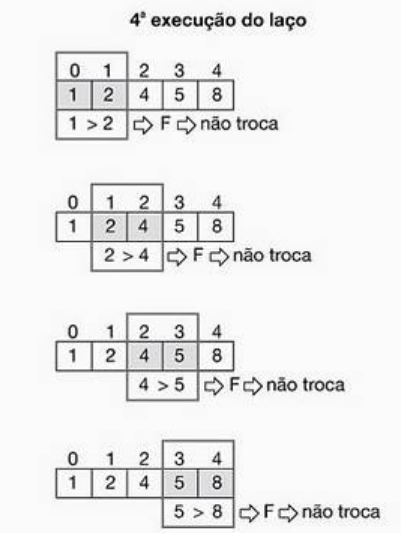

```python
Image(filename='./imagens/bubbleSort04.png')
```

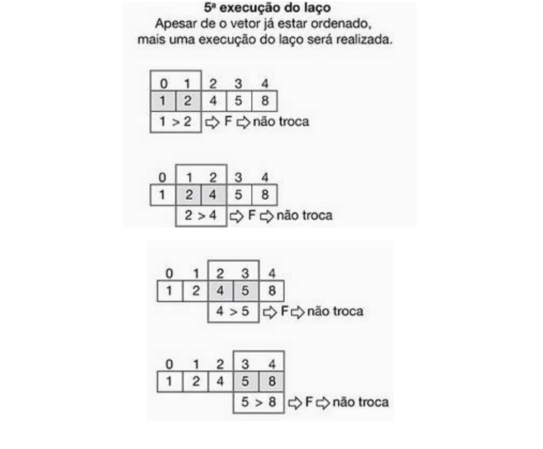

```python
Image(filename='./imagens/bubbleSort05.png')
```

## Implementação do Bubble Sort em Python

### Primeira Versão:

```python
n = int(input("Entre com o número de elementos de X: "))

#Criando a lista de 5 elementos a partir da entrada do usuário
X = [int(input("Digite o {0}{1}: ".format(i+1, chr(176)))) for i in range(n)]
print("O vetor de entrada é:  ")
print(X)
#Ordenação de forma crescente, a partir do número de elementos em X

#Laço com a quantidade de elementos do vetor
for k in range(1, n+1):
    #Laço que percorre da primeiira à penultima posição do vetor
    for i in range(0, n-1):
        if(X[i] > X[i+1]):
            X[i], X[i+1] = X[i+1], X[i]

print("O vetor ordenado é: ")
print(X)
```

### Análise de Complexidade do Algorítmo

O trecho importante para a anállise de complexidade do algorítmo é o que relaiza a comparação

'''

for k in range(1, n+1):

```
for i in range(0, n-1):

    if(X[i] > X[i+1]):

        X[i], X[i+1] = X[i+1], X[i]
```

'''

Quantas vezes o laço interno será executado, se a entrada for n=5?

Veja que temos $n * (n-1) = n^2-n \le c^2$, com $c=1$, $n \ge 1$, logo, a complexidade do algoritmo é $O(n^2)$.

## Versão Melhorada 1 do Bubble Sort

1. Cada elemento de posição i será comparada com o de posiçãoi i-1
2. Quando a ordenação procurada é encontrada, uma troca de posição de elementos é feita
3. Precisamos de um laço com a quantidade de elementos do vetor menos um
4. Dentro desse laço, um outro vetor percorre da última posição à posição j, fazendo com que as posições já ordenadas não sejam mais percorridas.

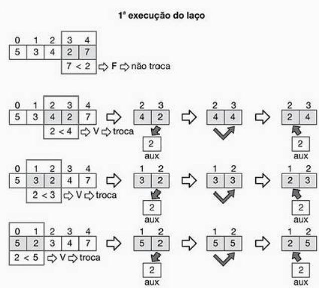

```python
Image(filename='./imagens/bubbleSort_v01_01.png')
```

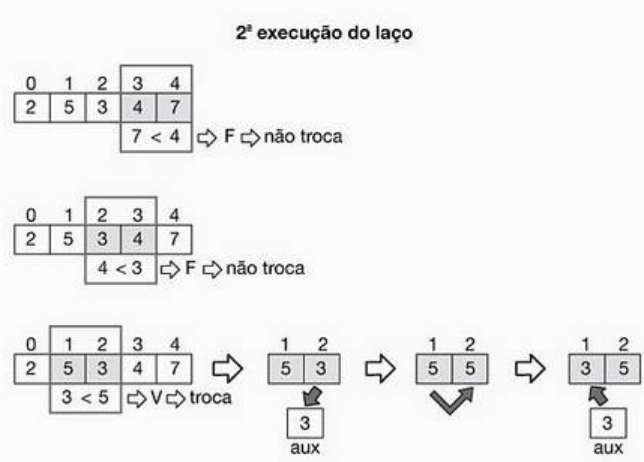

```python
Image(filename='./imagens/bubbleSort_v01_02.png')
```

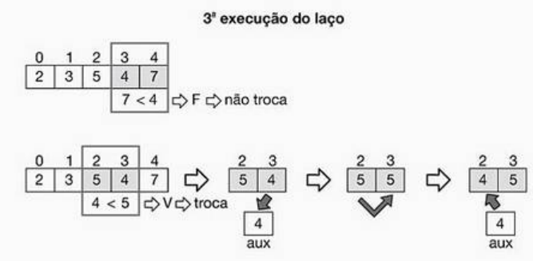

```python
Image(filename='./imagens/bubbleSort_v01_03.png')
```

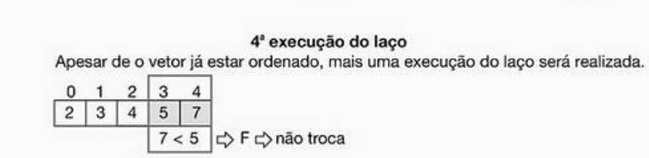

```python
Image(filename='./imagens/bubbleSort_v01_04.png')
```

### Implementação da nova versão em Python

```python
n = int(input("Entre com o número de elementos de X: "))

#Criando a lista de 5 elementos a partir da entrada do usuário
X = [int(input("Digite o {0}{1}: ".format(i+1, chr(176)))) for i in range(n)]
print("O vetor de entrada é:  ")
print(X)

for j in range(1, n):
    for i in range(n-1, j-1, -1):
        if X[i] < X[i-1]:
            X[i], X[i-1] = X[i-1], X[i]

print("O vetor ordenado é: ")
print(X)
```

```
Entre com o número de elementos de X: 9
Digite o 1°: 5
Digite o 2°: 9
Digite o 3°: 3
Digite o 4°: 0
Digite o 5°: 7
Digite o 6°: 2
Digite o 7°: 4
Digite o 8°: 1
Digite o 9°: 6
O vetor de entrada é:
[5, 9, 3, 0, 7, 2, 4, 1, 6]
O vetor ordenado é:
[0, 1, 2, 3, 4, 5, 6, 7, 9]
```

#### Análise da Complexidade

O techo de código que importa nesse caso é

'''

for j in range(1, n):

```
for i in range(n-1, j-1, -1):

    if X[i] < X[i-1]:

        X[i], X[i-1] = X[i-1], X[i]
```

'''

Quantas vezes cada laço será executado?

1. A laço superior será executado (n-1) vezes.
2. Já o número de vezes que o laço interno irá executar depende do valor de j.
3. Para j=1, o laço interno executa 4 vezes, para j=2 o laço executa será executado 3 vezes, para j= 3, duas vezes e uma para j=4.

Assim, o número de comparações, para um vetor de tamanho $n$ será: $((n-1)+...+3+2+1$.

Com isso chegamos ao seguinte somatório:

$T(n) = \sum_{i=1}^{n-1} = \frac{(1+n-1)(n-1)}{2} = \frac{n^{2}-n}{2}$

Ou seja, o algoritmo é de ordem $O(n^{2})$

## Versão Melhorada 2 do Bubble Sort

1. Comparação entre elementos de um vetor de tamanho n
2. Cada elemento de posição i será comparado com o de posição i+1
3. Quando a ordenação que se busca é encontrada, uma troca de posição é feita entre os dados
4. Laço com a quantidade de elemento será executada enquanto houver troca
5. Um laço interno será executado, percorrendo da primeira à penúltima posição do vetor.

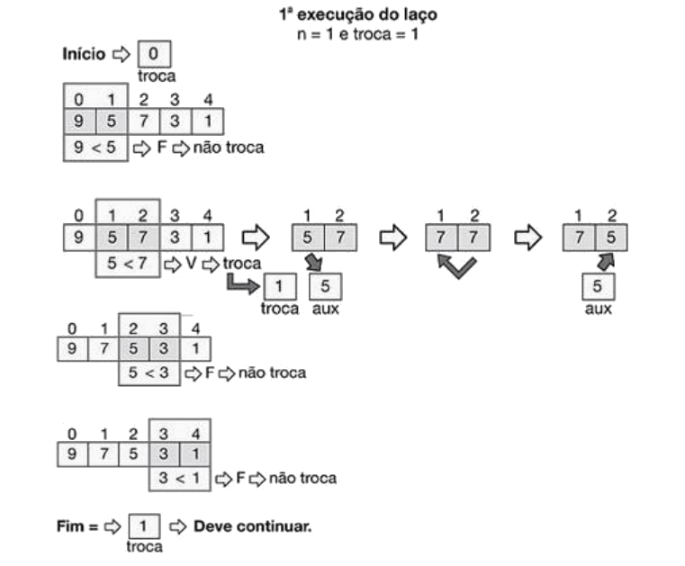

```python
Image(filename='./imagens/bubbleSort_v02_01.png')
```

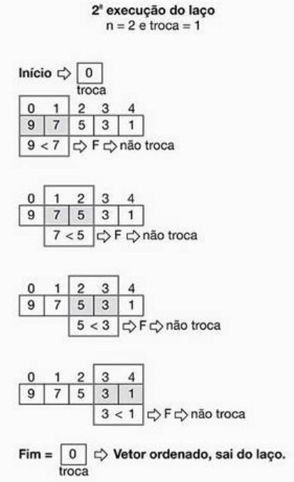

```python
Image(filename='./imagens/bubbleSort_v02_02.png')
```

### Implementação em Python

```python
n = int(input("Entre com o número de elementos de X: "))

#Criando a lista de 5 elementos a partir da entrada do usuário
X = [int(input("Digite o {0}{1}: ".format(i+1, chr(176)))) for i in range(n)]
print("O vetor de entrada é:  ")
print(X)

troca = True

#Ordenação de forma decrescente

#Laço com a quantidade de elementos do vetor e enquanto houver troca
for  k in range(1, n+1):
    troca = False
    for i in range(0, n-1):
        if X[i] < X[i+1]:
            troca = True
            X[i], X[i+1] = X[i+1], X[i]
    if troca is False:
        break


print("O vetor ordenado é: ")
print(X)
```

```
Entre com o número de elementos de X: 5
Digite o 1°: 1
Digite o 2°: 3
Digite o 3°: 9
Digite o 4°: 8
Digite o 5°: 8
O vetor de entrada é:
[1, 3, 9, 8, 8]
O vetor ordenado é:
[9, 8, 8, 3, 1]
```

### Exercícios

1. Qual a complexidade do algoritmo melhorado versão 2 do Bubble sort?
2. Execute as três versões do código Bubble sort e faça uma comparação de tempo de execução para cada caso, para um vetor de tamanho 10000. Para isso, use também como base o seguinte código em Python:

```python
import time
import random
t0 = time.time()
time.sleep(2)
t1 = time.time()
deltaT = t1 - t0
print(deltaT)

meusNumeros = random.sample(range(100), 10)
print(meusNumeros)
```

```
2.002368450164795
[0, 18, 36, 58, 77, 86, 32, 45, 59, 46]
```

1. Rode o Bubble Sort melhorado versão 2, 10000 vezes, em que cada rodada deve ser gerado um vetor aleatório, de tamanho 1000. Para cada rodada, armazene o tempo de execução em uma tabela. Compare os tempos de execução. São sempre iguais? Se existe diferença, qual o motivo para essa variação?